# Pruebas de raiz unitaria

Miguel G.

13/10/2022

Vamos a realizar pruebas de raiz unitaria para determinar si mis series de tiempo son estacionarias o no.

```r
rm(list=ls())

setwd("C:/Users/Miike/OneDrive - ITESO/01 Documentos/O2022/pronosticos/arima")

library(tseries)
library(readxl)

pib <- read_excel("pruebas_raiz.xlsx", sheet="us_pib")

ventas <- read_excel("pruebas_raiz.xlsx", sheet="ventas_papel")

quimico <- read_excel("pruebas_raiz.xlsx", sheet="quimico")

pib <- ts(pib$ln_gdp, start = c(1952,1), frequency = 4)

quimico <- ts(quimico$viscosidad, start = c(2000,1), frequency = 52)

venta <- ts(ventas$ventas, start = c(2000,1), frequency = 12)
```

Para realizar la prueba de raiz unitaria utilizamos la función adf.test.

# PIB

Grafica del PIB

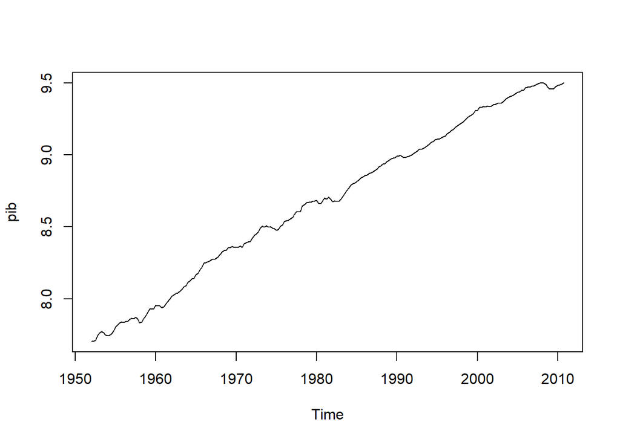

```r
ts.plot(pib)
```

Realizamos la prueba Dickey-fuller aumentada:

```r
adf.test(pib)
```

```
##
##  Augmented Dickey-Fuller Test
##
## data:  pib
## Dickey-Fuller = -1.33, Lag order = 6, p-value = 0.8575
## alternative hypothesis: stationary
```

Deseamos rechazar Ho, el valor-p es de 0.85, mayor a los tres niveles de significancia (10%, 5%, 1%). Por lo tanto la serie del PIB no es estacionaria.

Necesitamos transformar la serie de tiempo para encontrar el orden de integración.

Calculamos la serie de primeras diferencias.

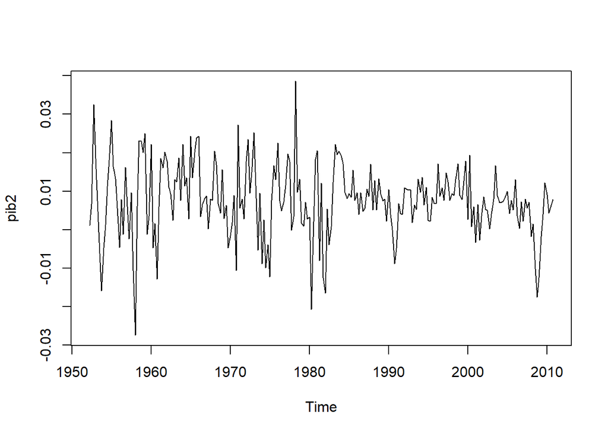

```r
pib2 <- diff(pib)

ts.plot(pib2)
```

Realizamos la prueba DF en la serie de primeras diferencias

```r
adf.test(pib2)
```

```
##
##  Augmented Dickey-Fuller Test
##
## data:  pib2
## Dickey-Fuller = -6.0406, Lag order = 6, p-value = 0.01
## alternative hypothesis: stationary
```

Existe evidencia para rechazar Ho, por lo tanto, las primeras diferencias del PIB es estacionaria. La serie del PIB es integrada de orden 1.

En caso de que necesite generar más diferencias, añado en la función diff, la opción difference=d

```r
pib3 <- diff(pib, differences = 2)
```

# Ventas de papel

Prueba DF

```r
adf.test(venta)
```

```
##
##  Augmented Dickey-Fuller Test
##
## data:  venta
## Dickey-Fuller = -1.7786, Lag order = 4, p-value = 0.6685
## alternative hypothesis: stationary
```

Realizamos la prueba con las primeras diferencias

```r
adf.test(diff(venta))
```

```
##
##  Augmented Dickey-Fuller Test
##
## data:  diff(venta)
## Dickey-Fuller = -4.2053, Lag order = 4, p-value = 0.01
## alternative hypothesis: stationary
```

La serie de ventas es integrada de orden 1

# Quimico

Prueba DF

```r
adf.test(quimico)
```

```
##
##  Augmented Dickey-Fuller Test
##
## data:  quimico
## Dickey-Fuller = -5.1949, Lag order = 4, p-value = 0.01
## alternative hypothesis: stationary
```

Esta serie es integrada de orden 0.